# PA1_template

## Introduction

This is **course project 1** for **Reproducible Research** course.

## Description

The data for this assignment can be downloaded from the course web site:

- Dataset: Activity monitoring data [52K]

The variables included in this dataset are:

- steps: Number of steps taking in a 5-minute interval (missing values are coded as NA)
- date: The date on which the measurement was taken in YYYY-MM-DD format
- interval: Identifier for the 5-minute interval in which measurement was taken

The dataset is stored in a comma-separated-value (CSV) file and there are a total of 17,568 observations in this dataset.

## Reading in and unzipping the data

The data used is called **activity.csv** and can be dowloaded / unzipped

```r
if(!file.exists("./activity.csv")) {
file_url <- "https://d396qusza40orc.cloudfront.net/repdata%2Fdata%2Factivity.zip"
  file_name <- "activity.zip"
  download.file(file_url, file_name, method = "curl")
  unzip(file_name)
}
```

## Loading and preprocessing the data

The data is loaded into data frame called **mydata**:

```r
mydata <- read.csv("C:/Users/Brian/repdata_data_activity/activity.csv")
```

The variables of **date** and **interval** need to be correctly formatted in R:

```r
mydata$date <- as.Date(mydata$date)
mydata$interval <- as.factor(mydata$interval)
names(mydata)
```

```
## [1] "steps"    "date"     "interval"
```

```r
lapply(mydata, class)
```

```
## $steps
## [1] "integer"
##
## $date
## [1] "Date"
##
## $interval
## [1] "factor"
```

## What is mean total number of steps taken per day?

1. Calculate the total number of steps taken per day.
2. Histogram is created.
3. Calculate and report the mean and median of the total number of steps taken per day.

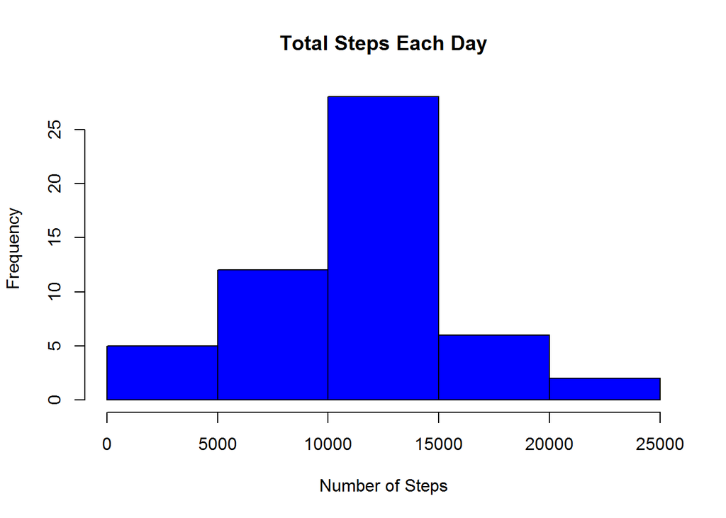

```r
meanstep <- aggregate(steps ~ date, mydata, sum)
hist(meanstep$steps, main =paste("Total Steps Each Day"), col="blue", xlab="Number of Steps")
```

```r
rmean <- mean(meanstep$steps)
print(rmean)
```

```
## [1] 10766.19
```

```r
rmedian <- median(meanstep$steps)
print(rmedian)
```

```
## [1] 10765
```

## What is the average daily activity pattern?

1. Average steps for each interval on all days will be computed.
2. Average number of steps per day by interval will be plotted.
3. Interval with most average steps will be found.

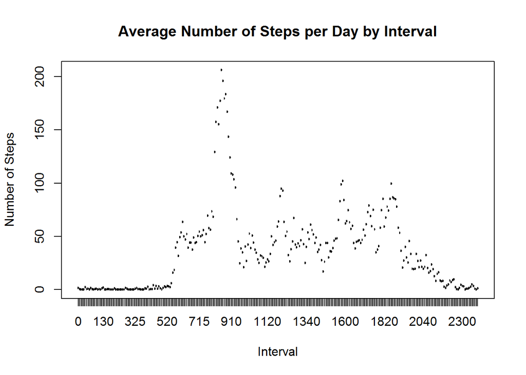

```r
intervalstep<- aggregate(steps ~ interval, mydata, mean)

plot(intervalstep$interval,intervalstep$steps, type="l", xlab="Interval", ylab="Number of Steps",main="Average Number of Steps per Day by Interval")
```

```r
max_interval <- intervalstep[which.max(intervalstep$steps),1]
print(max_interval)
```

```
## [1] 835
## 288 Levels: 0 5 10 15 20 25 30 35 40 45 50 55 100 105 110 115 120 ... 2355
```

## Imputing missing values

1. Calculate total number of missing

```r
incomplete <- sum(!complete.cases(mydata))
print(incomplete)
```

```
## [1] 2304
```

2. Impute missing values

```r
imputed_data <- transform(mydata, steps = ifelse(is.na(mydata$steps), intervalstep$steps[match(mydata$interval, intervalstep$interval)], mydata$steps))
imputed_data[as.character(imputed_data$date) == "2012-10-01", 1] <- 0
```

3. Recount total steps by day and create histogram.

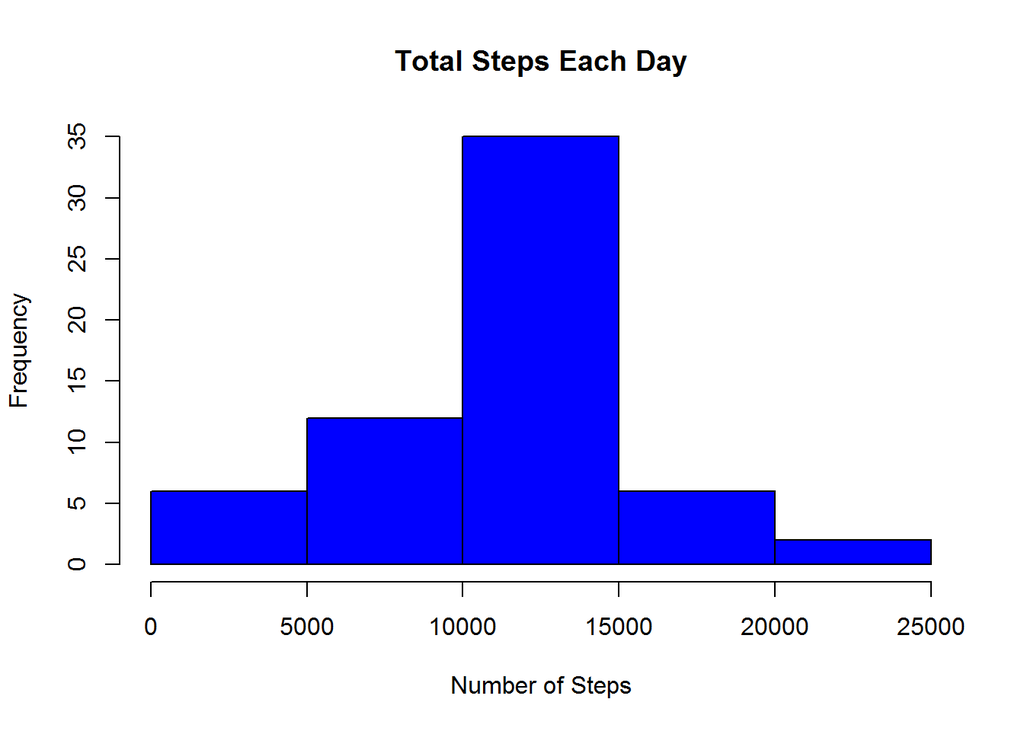

```r
meanstep_n <- aggregate(steps ~ date, imputed_data, sum)
hist(meanstep_n$steps, main = paste("Total Steps Each Day"), col="blue", xlab="Number of Steps")
```

4. Compute new mean and median after imputing data.

```r
rmean_n <- mean(meanstep_n$steps)
print(rmean_n)
```

```
## [1] 10589.69
```

```r
rmedian_n <- median(meanstep_n$steps)
print(rmedian_n)
```

```
## [1] 10766.19
```

By comparing the histogram, mean and median for one with and the other without missing values, one can note when missing data are imputed, :

1. Mean is lower.
2. Median is slightly higher.

## Are there differences in activity patterns between weekdays and weekends?

Using **weekdays()** function, creating a new factor variable with two level, “weekday” and “weekend”

```r
weekdays <- c("Monday", "Tuesday", "Wednesday", "Thursday", "Friday")
imputed_data$dow = as.factor(ifelse(is.element(weekdays(as.Date(imputed_data$date)),weekdays), "Weekday", "Weekend"))

intervalstep_n <- aggregate(steps ~ interval + dow, imputed_data, mean)

library(lattice)
```

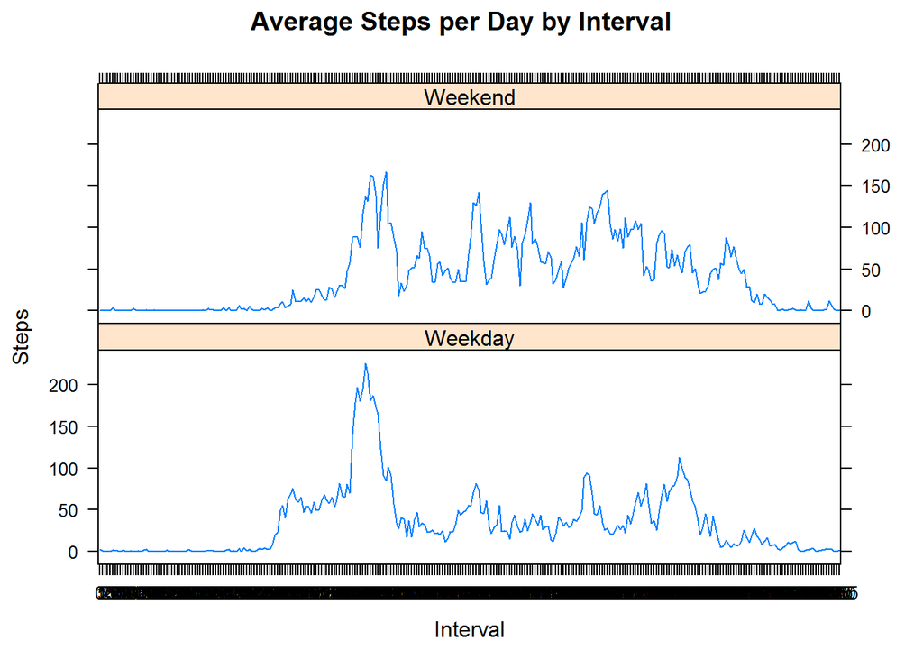

```r
xyplot(intervalstep_n$steps ~ intervalstep_n$interval|intervalstep_n$dow, main="Average Steps per Day by Interval",xlab="Interval", ylab="Steps",layout=c(1,2), type="l")
```